# Association Rules Project

# Problem Statement

We want to assist the retailer and help them to sell more products using an Amazon style “People who bought this also bought:” system.

# Suggested Solution

Using Association rules I can find common itemsets that are bought together to help the retailer start with the most popular item sets.

# 1.Load libraries

Here I will load in dplyr, arules and arulesViz. Dplyr is a very good tool for data transformation this will help me get the data into a suitable state to analyse the data. Arules is used to analyse data to find common itemsets and association rules. ArulesViz enables visualisation of the results we gain from the arules package.

```r
library(dplyr)
library(arules)
library(arulesViz)
```

# 2.Set the working directory

```r
setwd("C:/Users/Ashley Rainbow/Desktop/Data Fellowship/data-fellowship/Association Rules/Association Rules Project/Association Rules project 2")
```

# 3.Import the data

```r
orders <- read.csv('Peak Association Rules.csv')
```

# 4.Check the data

This allows me to see if the data is in a suitable structure.

```r
head(orders)
```

```
  Order.Number                                              Item.Name
1    145746169       30 mm f/1.4 DC DN Standard Prime Lens - for Sony
2    145746108                                 WM4221 Tilt TV Bracket
3    145746091 Retro SWPS3020PN 3-piece Non-stick Saucepan Set - Pink
4    145746011            Heavy-Duty Swing Arm Full Motion TV Bracket
5    145745994                          Vigor 2.0 PC Speakers - Brown
6    145745737                               SDC1140 TV Stand - Black
```

```r
str(orders)
```

```
'data.frame':   33998 obs. of  2 variables:
 $ Order.Number: int  145746169 145746108 145746091 145746011 145745994 145745737 145745495 145745424 145745424 145745393 ...
 $ Item.Name   : Factor w/ 1714 levels "05X Black Toner Cartridge",..: 82 1673 1175 691 1642 1283 1435 1160 1135 469 ...
```

# 7.Group products by order number

This allows me to show products bought in an order as one collective ‘basket’.

```r
order_baskets = orders %>%
  group_by(Order.Number) %>% summarise(order_basket = as.vector(list(Item.Name)))
```

# 8.View a sample order_basket

Check to see if dataframe is set up correctly (order basket is set up as a list of factors).

[output not shown]

# 9.Convert to sparse matrix

To view itemsets and association rules the dataframe needs to be converted to a sparse matrix.

```r
sparse_data <- as(order_baskets$order_basket, "transactions")
```

```
removing duplicated items in transactions
```

# 10.Inspect the sparse matrix

```r
summary(sparse_data)
```

```
transactions as itemMatrix in sparse format with
 31323 rows (elements/itemsets/transactions) and
 1714 columns (items) and a density of 0.0006034538

most frequent items:
Heavy-Duty Swing Arm Full Motion TV Bracket    Swing Arm Full Motion TV Bracket - Black         MediaPad T3 7" Tablet - 16 GB, Grey
                                       1295                                         723                                         685
                 RHSM1001 Steam Mop - White       PIXPRO AZ252-BK Bridge Camera - Black                                     (Other)
                                        684                                         531                                       28480

element (itemset/transaction) length distribution:
sizes
    1     2     3     4     5     6     7     8
30484   689    95    37     9     6     2     1

   Min. 1st Qu.  Median    Mean 3rd Qu.    Max.
  1.000   1.000   1.000   1.034   1.000   8.000

includes extended item information - examples:
                                 labels
1             05X Black Toner Cartridge
2   10 x 30 mm IS II Binoculars - Black
3 100 x 150 mm Photo Paper - 100 Sheets
```

```r
inspect(sparse_data[1:20])
```

```
     items
[1]  {RHM2017 Compact Solo Microwave - Silver}
[2]  {Coco Loco LSHD24 Hair Dryer - Pink}
[3]  {Purity 22851 Jug Kettle - Transparent}
[4]  {Snowdon 20441 Jug Kettle - Stainless Steel}
[5]  {Heavy-Duty Swing Arm Full Motion TV Bracket}
[6]  {RS-60E3 Camera Remote Control}
[7]  {WM4421 Tilt TV Bracket}
[8]  {RHM2076S Solo Microwave - Silver}
[9]  {MediaPad M5 8.4" 4G Tablet - 32 GB - Space Grey}
[10] {TTD404F Fixed TV Bracket}
[11] {LC43J890DKUXEN Super Wide Full HD 43" Curved LED Monitor - Dark Blue Grey}
[12] {RHSM1001 Steam Mop - White}
[13] {TWM441 Tilt}
[14] {MediaPad T3 7" Tablet - 16 GB, Grey}
[15] {Retro 2-piece Non-stick Frying Pan Set - Black,Retro SWPS3020BN 3-piece Non-Stick Saucepan Set - Black}
[16] {RHM2076B Solo Microwave - Black}
[17] {Ultra Slim Tilt TV Bracket}
[18] {Pro 235 Smooth Hair Straightener - Red}
[19] {RHM2017 Compact Solo Microwave - Silver}
[20] {Pro VMA4400-100EUS Rechargeable Battery - White}
```

# 11.Plot the most popular products

This gives me an idea of what products sell well and what to keep an eye out for later on.

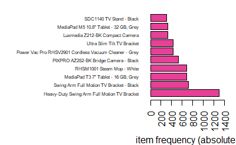

```r
par(mar = c(4, 5, 1, 1))
itemFrequencyPlot(sparse_data, topN = 10, type = 'absolute', cex.names = 0.5, horiz = TRUE, xlim = c(0, max(1400)), col = c("#E64097"))
```

# 12.Create a rule for the most frequent itemsets

This finds the most common data sets with a support greater than 0.0004.

```r
rules = apriori(data = sparse_data, parameter = list(target = "frequent itemsets",  support = 0.0004, minlen = 2), control = list(verbose = FALSE))
rules = sort(rules, by = 'support', decreasing = TRUE)
inspect(rules[1])
```

```
    items                                                                                support      count
[1] {Retro SK34021GRN Traditional Kettle - Grey,Retro ST19020GRN 4-Slice Toaster - Grey} 0.0008619864 27
```

# 13.Create a dataframe base on rules data.

This gives me a dataframe of the most popular itemsets.

```r
order_rules_df <- DATAFRAME(sort(rules, by = "support", decreasing = FALSE))
```

# 14.Create a barplot from the orders dataframe.

I use this to show the top itemsets. This give a clear demonstration of the top itemsets and how much support they have.

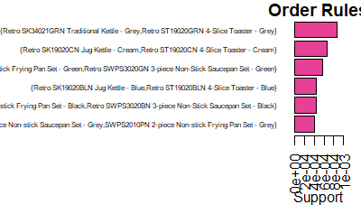

```r
par(mar = c(5,17, 1, 1))
barplot(order_rules_df$support, main = "Order Rules", xlab = "Support", names.arg = order_rules_df$items, horiz = TRUE, las = 2, cex.names = 0.5, xlim=c(0, max = 0.001), col = c("#E64097"))
```

# 15.Finding the most common itemsets

Uses apriori to find most common itemsets with support of at least 0.0004 and confidence of greater than 0.2

```r
rules = apriori(data = sparse_data, parameter = list(support = 0.0004, confidence = 0.2, minlen = 2))
```

```
Apriori

Parameter specification:
 confidence minval smax arem  aval originalSupport maxtime support minlen maxlen target   ext
        0.2    0.1    1 none FALSE            TRUE       5   4e-04      2     10  rules FALSE

Algorithmic control:
 filter tree heap memopt load sort verbose
    0.1 TRUE TRUE  FALSE TRUE    2    TRUE

Absolute minimum support count: 12

set item appearances ...[0 item(s)] done [0.00s].
set transactions ...[1714 item(s), 31323 transaction(s)] done [0.02s].
sorting and recoding items ... [513 item(s)] done [0.00s].
creating transaction tree ... done [0.00s].
checking subsets of size 1 2 done [0.00s].
writing ... [12 rule(s)] done [0.00s].
creating S4 object  ... done [0.00s].
```

```r
summary(rules)
```

```
set of 12 rules

rule length distribution (lhs + rhs):sizes
 2
12

   Min. 1st Qu.  Median    Mean 3rd Qu.    Max.
      2       2       2       2       2       2

summary of quality measures:
    support            confidence          lift           count
 Min.   :0.0004150   Min.   :0.2642   Min.   :124.3   Min.   :13.00
 1st Qu.:0.0004470   1st Qu.:0.3304   1st Qu.:253.8   1st Qu.:14.00
 Median :0.0005108   Median :0.3388   Median :303.3   Median :16.00
 Mean   :0.0005693   Mean   :0.3994   Mean   :282.9   Mean   :17.83
 3rd Qu.:0.0006704   3rd Qu.:0.4368   3rd Qu.:336.8   3rd Qu.:21.00
 Max.   :0.0008620   Max.   :0.6364   Max.   :376.1   Max.   :27.00

mining info:
        data ntransactions support confidence
 sparse_data         31323   4e-04        0.2
```

```r
inspect(rules[1:10])
```

```
     lhs                                                          rhs                                                       support      confidence lift     count
[1]  {Retro 2-piece Non-stick Frying Pan Set - Black}          => {Retro SWPS3020BN 3-piece Non-Stick Saucepan Set - Black} 0.0004469559 0.6363636  376.0909 14
[2]  {Retro SWPS3020BN 3-piece Non-Stick Saucepan Set - Black} => {Retro 2-piece Non-stick Frying Pan Set - Black}          0.0004469559 0.2641509  376.0909 14
[3]  {Retro SWPS3020GRN 3-piece Non-stick Saucepan Set - Grey} => {SWPS2010PN 2-piece Non-stick Frying Pan Set - Grey}      0.0004150305 0.3823529  307.0882 13
[4]  {SWPS2010PN 2-piece Non-stick Frying Pan Set - Grey}      => {Retro SWPS3020GRN 3-piece Non-stick Saucepan Set - Grey} 0.0004150305 0.3333333  307.0882 13
[5]  {Retro 2-piece Non-stick Frying Pan Set - Green}          => {Retro SWPS3020GN 3-piece Non-Stick Saucepan Set - Green} 0.0005746576 0.5806452  336.8065 18
[6]  {Retro SWPS3020GN 3-piece Non-Stick Saucepan Set - Green} => {Retro 2-piece Non-stick Frying Pan Set - Green}          0.0005746576 0.3333333  336.8065 18
[7]  {Retro ST19020CN 4-Slice Toaster - Cream}                 => {Retro SK19020CN Jug Kettle - Cream}                      0.0006704339 0.5833333  299.5369 21
[8]  {Retro SK19020CN Jug Kettle - Cream}                      => {Retro ST19020CN 4-Slice Toaster - Cream}                 0.0006704339 0.3442623  299.5369 21
[9]  {Retro ST19020BLN 4-Slice Toaster - Blue}                 => {Retro SK19020BLN Jug Kettle - Blue}                      0.0004469559 0.3888889  253.7743 14
[10] {Retro SK19020BLN Jug Kettle - Blue}                      => {Retro ST19020BLN 4-Slice Toaster - Blue}                 0.0004469559 0.2916667  253.7743 14
```

# 16.Plotting most common sets of items being bought together.

This gives a visual representation of the most common itemsets and the relationship between those products.

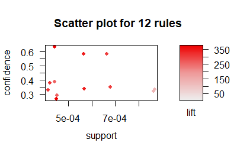

```r
plot(rules, method = 'scatterplot', measure = c("support", "confidence"), shading = "lift", jitter = 1)
```

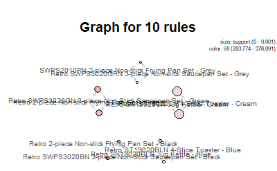

```r
plot(rules[1:10], method = 'graph', control = list(cex = 0.65))
```

# 17.Viewing rule sorted by sorted by confidence.

This gives me a different perspective on the item sets seeing the top 10 most confident products.

```r
inspect(sort(rules, by = 'confidence', decreasing = TRUE)[1:10])
```

```
     lhs                                                          rhs                                                       support      confidence lift     count
[1]  {Retro 2-piece Non-stick Frying Pan Set - Black}          => {Retro SWPS3020BN 3-piece Non-Stick Saucepan Set - Black} 0.0004469559 0.6363636  376.0909 14
[2]  {Retro ST19020CN 4-Slice Toaster - Cream}                 => {Retro SK19020CN Jug Kettle - Cream}                      0.0006704339 0.5833333  299.5369 21
[3]  {Retro 2-piece Non-stick Frying Pan Set - Green}          => {Retro SWPS3020GN 3-piece Non-Stick Saucepan Set - Green} 0.0005746576 0.5806452  336.8065 18
[4]  {Retro ST19020BLN 4-Slice Toaster - Blue}                 => {Retro SK19020BLN Jug Kettle - Blue}                      0.0004469559 0.3888889  253.7743 14
[5]  {Retro SWPS3020GRN 3-piece Non-stick Saucepan Set - Grey} => {SWPS2010PN 2-piece Non-stick Frying Pan Set - Grey}      0.0004150305 0.3823529  307.0882 13
[6]  {Retro SK19020CN Jug Kettle - Cream}                      => {Retro ST19020CN 4-Slice Toaster - Cream}                 0.0006704339 0.3442623  299.5369 21
[7]  {SWPS2010PN 2-piece Non-stick Frying Pan Set - Grey}      => {Retro SWPS3020GRN 3-piece Non-stick Saucepan Set - Grey} 0.0004150305 0.3333333  307.0882 13
[8]  {Retro SWPS3020GN 3-piece Non-Stick Saucepan Set - Green} => {Retro 2-piece Non-stick Frying Pan Set - Green}          0.0005746576 0.3333333  336.8065 18
[9]  {Retro ST19020GRN 4-Slice Toaster - Grey}                 => {Retro SK34021GRN Traditional Kettle - Grey}              0.0008619864 0.3333333  124.2976 27
[10] {Retro SK34021GRN Traditional Kettle - Grey}              => {Retro ST19020GRN 4-Slice Toaster - Grey}                 0.0008619864 0.3214286  124.2976 27
```

# 18.Viewing rule sorted by sorted by support.

As above this shows you the top 10 most popular item sets sorted by support.

```r
inspect(sort(rules, by = 'support', decreasing = TRUE)[1:10])
```

```
     lhs                                                          rhs                                                       support      confidence lift     count
[1]  {Retro SK34021GRN Traditional Kettle - Grey}              => {Retro ST19020GRN 4-Slice Toaster - Grey}                 0.0008619864 0.3214286  124.2976 27
[2]  {Retro ST19020GRN 4-Slice Toaster - Grey}                 => {Retro SK34021GRN Traditional Kettle - Grey}              0.0008619864 0.3333333  124.2976 27
[3]  {Retro ST19020CN 4-Slice Toaster - Cream}                 => {Retro SK19020CN Jug Kettle - Cream}                      0.0006704339 0.5833333  299.5369 21
[4]  {Retro SK19020CN Jug Kettle - Cream}                      => {Retro ST19020CN 4-Slice Toaster - Cream}                 0.0006704339 0.3442623  299.5369 21
[5]  {Retro 2-piece Non-stick Frying Pan Set - Green}          => {Retro SWPS3020GN 3-piece Non-Stick Saucepan Set - Green} 0.0005746576 0.5806452  336.8065 18
[6]  {Retro SWPS3020GN 3-piece Non-Stick Saucepan Set - Green} => {Retro 2-piece Non-stick Frying Pan Set - Green}          0.0005746576 0.3333333  336.8065 18
[7]  {Retro 2-piece Non-stick Frying Pan Set - Black}          => {Retro SWPS3020BN 3-piece Non-Stick Saucepan Set - Black} 0.0004469559 0.6363636  376.0909 14
[8]  {Retro SWPS3020BN 3-piece Non-Stick Saucepan Set - Black} => {Retro 2-piece Non-stick Frying Pan Set - Black}          0.0004469559 0.2641509  376.0909 14
[9]  {Retro ST19020BLN 4-Slice Toaster - Blue}                 => {Retro SK19020BLN Jug Kettle - Blue}                      0.0004469559 0.3888889  253.7743 14
[10] {Retro SK19020BLN Jug Kettle - Blue}                      => {Retro ST19020BLN 4-Slice Toaster - Blue}                 0.0004469559 0.2916667  253.7743 14
```

# 19.Viewing the rule sorted by lift.

As above this shows you the top 10 most popular item sets sorted by lift.

```r
inspect(sort(rules, by = 'lift', decreasing = TRUE)[1:10])
```

```
     lhs                                                          rhs                                                       support      confidence lift     count
[1]  {Retro 2-piece Non-stick Frying Pan Set - Black}          => {Retro SWPS3020BN 3-piece Non-Stick Saucepan Set - Black} 0.0004469559 0.6363636  376.0909 14
[2]  {Retro SWPS3020BN 3-piece Non-Stick Saucepan Set - Black} => {Retro 2-piece Non-stick Frying Pan Set - Black}          0.0004469559 0.2641509  376.0909 14
[3]  {Retro 2-piece Non-stick Frying Pan Set - Green}          => {Retro SWPS3020GN 3-piece Non-Stick Saucepan Set - Green} 0.0005746576 0.5806452  336.8065 18
[4]  {Retro SWPS3020GN 3-piece Non-Stick Saucepan Set - Green} => {Retro 2-piece Non-stick Frying Pan Set - Green}          0.0005746576 0.3333333  336.8065 18
[5]  {Retro SWPS3020GRN 3-piece Non-stick Saucepan Set - Grey} => {SWPS2010PN 2-piece Non-stick Frying Pan Set - Grey}      0.0004150305 0.3823529  307.0882 13
[6]  {SWPS2010PN 2-piece Non-stick Frying Pan Set - Grey}      => {Retro SWPS3020GRN 3-piece Non-stick Saucepan Set - Grey} 0.0004150305 0.3333333  307.0882 13
[7]  {Retro ST19020CN 4-Slice Toaster - Cream}                 => {Retro SK19020CN Jug Kettle - Cream}                      0.0006704339 0.5833333  299.5369 21
[8]  {Retro SK19020CN Jug Kettle - Cream}                      => {Retro ST19020CN 4-Slice Toaster - Cream}                 0.0006704339 0.3442623  299.5369 21
[9]  {Retro ST19020BLN 4-Slice Toaster - Blue}                 => {Retro SK19020BLN Jug Kettle - Blue}                      0.0004469559 0.3888889  253.7743 14
[10] {Retro SK19020BLN Jug Kettle - Blue}                      => {Retro ST19020BLN 4-Slice Toaster - Blue}                 0.0004469559 0.2916667  253.7743 14
```

# 20.Finding the most common set of items bought with higher support but lower confidence.

```r
rules = apriori(data = sparse_data, parameter = list(support = 0.00055 , confidence = 0.1 , minlen = 2, maxlen = 3))
```

```
Apriori

Parameter specification:
 confidence minval smax arem  aval originalSupport maxtime support minlen maxlen target   ext
        0.1    0.1    1 none FALSE            TRUE       5 0.00055      2      3  rules FALSE

Algorithmic control:
 filter tree heap memopt load sort verbose
    0.1 TRUE TRUE  FALSE TRUE    2    TRUE

Absolute minimum support count: 17

set item appearances ...[0 item(s)] done [0.00s].
set transactions ...[1714 item(s), 31323 transaction(s)] done [0.01s].
sorting and recoding items ... [411 item(s)] done [0.00s].
creating transaction tree ... done [0.01s].
checking subsets of size 1 2 done [0.00s].
writing ... [6 rule(s)] done [0.00s].
creating S4 object  ... done [0.00s].
```

```r
summary(rules)
```

```
set of 6 rules

rule length distribution (lhs + rhs):sizes
2
6

   Min. 1st Qu.  Median    Mean 3rd Qu.    Max.
      2       2       2       2       2       2

summary of quality measures:
    support            confidence          lift           count
 Min.   :0.0005747   Min.   :0.3214   Min.   :124.3   Min.   :18.00
 1st Qu.:0.0005986   1st Qu.:0.3333   1st Qu.:168.1   1st Qu.:18.75
 Median :0.0006704   Median :0.3388   Median :299.5   Median :21.00
 Mean   :0.0007024   Mean   :0.4161   Mean   :253.5   Mean   :22.00
 3rd Qu.:0.0008141   3rd Qu.:0.5215   3rd Qu.:327.5   3rd Qu.:25.50
 Max.   :0.0008620   Max.   :0.5833   Max.   :336.8   Max.   :27.00

mining info:
        data ntransactions support confidence
 sparse_data         31323 0.00055        0.1
```

```r
inspect(rules)
```

```
    lhs                                                          rhs                                                       support      confidence lift     count
[1] {Retro 2-piece Non-stick Frying Pan Set - Green}          => {Retro SWPS3020GN 3-piece Non-Stick Saucepan Set - Green} 0.0005746576 0.5806452  336.8065 18
[2] {Retro SWPS3020GN 3-piece Non-Stick Saucepan Set - Green} => {Retro 2-piece Non-stick Frying Pan Set - Green}          0.0005746576 0.3333333  336.8065 18
[3] {Retro ST19020CN 4-Slice Toaster - Cream}                 => {Retro SK19020CN Jug Kettle - Cream}                      0.0006704339 0.5833333  299.5369 21
[4] {Retro SK19020CN Jug Kettle - Cream}                      => {Retro ST19020CN 4-Slice Toaster - Cream}                 0.0006704339 0.3442623  299.5369 21
[5] {Retro SK34021GRN Traditional Kettle - Grey}              => {Retro ST19020GRN 4-Slice Toaster - Grey}                 0.0008619864 0.3214286  124.2976 27
[6] {Retro ST19020GRN 4-Slice Toaster - Grey}                 => {Retro SK34021GRN Traditional Kettle - Grey}              0.0008619864 0.3333333  124.2976 27
```

# 21.Plotting most common sets of items being bought together with low confidence but high support.

This allows me to visualise the new item sets and compare to previous sets.

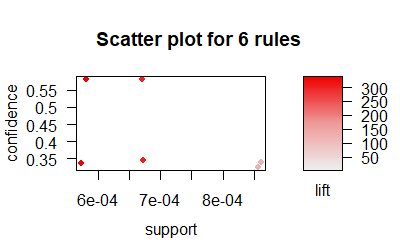

```r
plot(rules, method = 'scatterplot', measure = c("support", "confidence"), shading = "lift", jitter = 1)
```

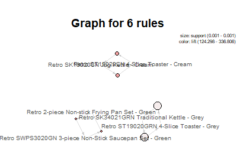

```r
plot(rules, method = "graph", control = list (cex = 0.65))
```

# 22.Creating Cream Toaster subset

This step is used to view the products commonly bought with a cream toaster.

```r
rules = apriori(data = sparse_data, parameter = list(support = 0.00003, confidence = 0.5, minlen = 2))
```

```
Apriori

Parameter specification:
 confidence minval smax arem  aval originalSupport maxtime support minlen maxlen target   ext
        0.5    0.1    1 none FALSE            TRUE       5   3e-05      2     10  rules FALSE

Algorithmic control:
 filter tree heap memopt load sort verbose
    0.1 TRUE TRUE  FALSE TRUE    2    TRUE

Absolute minimum support count: 0

set item appearances ...[0 item(s)] done [0.00s].
set transactions ...[1714 item(s), 31323 transaction(s)] done [0.01s].
sorting and recoding items ... [1714 item(s)] done [0.00s].
creating transaction tree ... done [0.01s].
checking subsets of size 1 2 3 4 5 6 7 8 done [0.02s].
writing ... [3286 rule(s)] done [0.01s].
creating S4 object  ... done [0.01s].
```

```r
cream_toaster_rule = sort(
  subset(rules, subset = rhs %in% 'Retro ST19020CN 4-Slice Toaster - Cream'),
  by = 'support', decreasing = T
)
inspect(cream_toaster_rule)
```

```
     lhs                                                        rhs                                            support confidence     lift count
[1]  {Retro SK19020CN Jug Kettle - Cream,
      Retro Towel Pole - Cream}                              => {Retro ST19020CN 4-Slice Toaster - Cream} 1.277017e-04  1.0000000 870.0833     4
[2]  {Retro Towel Pole - Cream,
      SM22080CN Retro Microwave with Grill - Cream}          => {Retro ST19020CN 4-Slice Toaster - Cream} 6.385084e-05  1.0000000 870.0833     2
[3]  {Retro SK19020CN Jug Kettle - Cream,
      SM22080CN Retro Microwave with Grill - Cream}          => {Retro ST19020CN 4-Slice Toaster - Cream} 6.385084e-05  1.0000000 870.0833     2
[4]  {Retro Bread Bin - Cream,
      Retro SK19020CN Jug Kettle - Cream}                    => {Retro ST19020CN 4-Slice Toaster - Cream} 6.385084e-05  0.6666667 580.0556     2
[5]  {Retro SK19020CN Jug Kettle - Cream,
      Retro Towel Pole - Cream,
      SM22080CN Retro Microwave with Grill - Cream}          => {Retro ST19020CN 4-Slice Toaster - Cream} 6.385084e-05  1.0000000 870.0833     2
[6]  {Retro 45-litre Rectangular Bin - Cream,
      Retro SWKA1020CN 1-litre Canisters - Cream, Pack of 3} => {Retro ST19020CN 4-Slice Toaster - Cream} 3.192542e-05  0.5000000 435.0417     1
[7]  {Retro 45-litre Rectangular Bin - Cream,
      Retro Bread Bin - Cream}                               => {Retro ST19020CN 4-Slice Toaster - Cream} 3.192542e-05  1.0000000 870.0833     1
[8]  {Retro SK19020CN Jug Kettle - Cream,
      SM22130CN Solo Microwave - Cream}                      => {Retro ST19020CN 4-Slice Toaster - Cream} 3.192542e-05  1.0000000 870.0833     1
[9]  {Retro SK19020CN Jug Kettle - Cream,
      Retro SM22070CN Solo Microwave - Cream}                => {Retro ST19020CN 4-Slice Toaster - Cream} 3.192542e-05  1.0000000 870.0833     1
[10] {Retro 2-piece Non-stick Frying Pan Set - Cream,
      Retro Towel Pole - Cream}                              => {Retro ST19020CN 4-Slice Toaster - Cream} 3.192542e-05  1.0000000 870.0833     1
[11] {Retro 2-piece Non-stick Frying Pan Set - Cream,
      Retro SK19020CN Jug Kettle - Cream}                    => {Retro ST19020CN 4-Slice Toaster - Cream} 3.192542e-05  1.0000000 870.0833     1
[12] {Retro Bread Bin - Cream,
      Retro Towel Pole - Cream}                              => {Retro ST19020CN 4-Slice Toaster - Cream} 3.192542e-05  0.5000000 435.0417     1
[13] {Retro SK19020CN Jug Kettle - Cream,
      Retro ST19020BLN 4-Slice Toaster - Blue}               => {Retro ST19020CN 4-Slice Toaster - Cream} 3.192542e-05  1.0000000 870.0833     1
[14] {Retro SK19020BLN Jug Kettle - Blue,
      Retro SK19020CN Jug Kettle - Cream}                    => {Retro ST19020CN 4-Slice Toaster - Cream} 3.192542e-05  1.0000000 870.0833     1
[15] {Retro 45-litre Rectangular Bin - Cream,
      Retro Bread Bin - Cream,
      Retro SWKA1020CN 1-litre Canisters - Cream, Pack of 3} => {Retro ST19020CN 4-Slice Toaster - Cream} 3.192542e-05  1.0000000 870.0833     1
[16] {Retro 2-piece Non-stick Frying Pan Set - Cream,
      Retro SK19020CN Jug Kettle - Cream,
      Retro Towel Pole - Cream}                              => {Retro ST19020CN 4-Slice Toaster - Cream} 3.192542e-05  1.0000000 870.0833     1
[17] {Retro Bread Bin - Cream,
      Retro SK19020CN Jug Kettle - Cream,
      Retro Towel Pole - Cream}                              => {Retro ST19020CN 4-Slice Toaster - Cream} 3.192542e-05  1.0000000 870.0833     1
[18] {Retro SK19020BLN Jug Kettle - Blue,
      Retro SK19020CN Jug Kettle - Cream,
      Retro ST19020BLN 4-Slice Toaster - Blue}               => {Retro ST19020CN 4-Slice Toaster - Cream} 3.192542e-05  1.0000000 870.0833     1
```

```r
lift_cream_toaster = sort(cream_toaster_rule, by = 'lift', decreasing = TRUE)
paste("Sorted by lift. ----------------------------------")
```

```
[1] "Sorted by lift. ----------------------------------"
```

```r
inspect(lift_cream_toaster)
```

```
     lhs                                                        rhs                                            support confidence     lift count
[1]  {Retro SK19020CN Jug Kettle - Cream,
      Retro Towel Pole - Cream}                              => {Retro ST19020CN 4-Slice Toaster - Cream} 1.277017e-04  1.0000000 870.0833     4
[2]  {Retro Towel Pole - Cream,
      SM22080CN Retro Microwave with Grill - Cream}          => {Retro ST19020CN 4-Slice Toaster - Cream} 6.385084e-05  1.0000000 870.0833     2
[3]  {Retro SK19020CN Jug Kettle - Cream,
      SM22080CN Retro Microwave with Grill - Cream}          => {Retro ST19020CN 4-Slice Toaster - Cream} 6.385084e-05  1.0000000 870.0833     2
[4]  {Retro SK19020CN Jug Kettle - Cream,
      Retro Towel Pole - Cream,
      SM22080CN Retro Microwave with Grill - Cream}          => {Retro ST19020CN 4-Slice Toaster - Cream} 6.385084e-05  1.0000000 870.0833     2
[5]  {Retro 45-litre Rectangular Bin - Cream,
      Retro Bread Bin - Cream}                               => {Retro ST19020CN 4-Slice Toaster - Cream} 3.192542e-05  1.0000000 870.0833     1
[6]  {Retro SK19020CN Jug Kettle - Cream,
      SM22130CN Solo Microwave - Cream}                      => {Retro ST19020CN 4-Slice Toaster - Cream} 3.192542e-05  1.0000000 870.0833     1
[7]  {Retro SK19020CN Jug Kettle - Cream,
      Retro SM22070CN Solo Microwave - Cream}                => {Retro ST19020CN 4-Slice Toaster - Cream} 3.192542e-05  1.0000000 870.0833     1
[8]  {Retro 2-piece Non-stick Frying Pan Set - Cream,
      Retro Towel Pole - Cream}                              => {Retro ST19020CN 4-Slice Toaster - Cream} 3.192542e-05  1.0000000 870.0833     1
[9]  {Retro 2-piece Non-stick Frying Pan Set - Cream,
      Retro SK19020CN Jug Kettle - Cream}                    => {Retro ST19020CN 4-Slice Toaster - Cream} 3.192542e-05  1.0000000 870.0833     1
[10] {Retro SK19020CN Jug Kettle - Cream,
      Retro ST19020BLN 4-Slice Toaster - Blue}               => {Retro ST19020CN 4-Slice Toaster - Cream} 3.192542e-05  1.0000000 870.0833     1
[11] {Retro SK19020BLN Jug Kettle - Blue,
      Retro SK19020CN Jug Kettle - Cream}                    => {Retro ST19020CN 4-Slice Toaster - Cream} 3.192542e-05  1.0000000 870.0833     1
[12] {Retro 45-litre Rectangular Bin - Cream,
      Retro Bread Bin - Cream,
      Retro SWKA1020CN 1-litre Canisters - Cream, Pack of 3} => {Retro ST19020CN 4-Slice Toaster - Cream} 3.192542e-05  1.0000000 870.0833     1
[13] {Retro 2-piece Non-stick Frying Pan Set - Cream,
      Retro SK19020CN Jug Kettle - Cream,
      Retro Towel Pole - Cream}                              => {Retro ST19020CN 4-Slice Toaster - Cream} 3.192542e-05  1.0000000 870.0833     1
[14] {Retro Bread Bin - Cream,
      Retro SK19020CN Jug Kettle - Cream,
      Retro Towel Pole - Cream}                              => {Retro ST19020CN 4-Slice Toaster - Cream} 3.192542e-05  1.0000000 870.0833     1
[15] {Retro SK19020BLN Jug Kettle - Blue,
      Retro SK19020CN Jug Kettle - Cream,
      Retro ST19020BLN 4-Slice Toaster - Blue}               => {Retro ST19020CN 4-Slice Toaster - Cream} 3.192542e-05  1.0000000 870.0833     1
[16] {Retro Bread Bin - Cream,
      Retro SK19020CN Jug Kettle - Cream}                    => {Retro ST19020CN 4-Slice Toaster - Cream} 6.385084e-05  0.6666667 580.0556     2
[17] {Retro 45-litre Rectangular Bin - Cream,
      Retro SWKA1020CN 1-litre Canisters - Cream, Pack of 3} => {Retro ST19020CN 4-Slice Toaster - Cream} 3.192542e-05  0.5000000 435.0417     1
[18] {Retro Bread Bin - Cream,
      Retro Towel Pole - Cream}                              => {Retro ST19020CN 4-Slice Toaster - Cream} 3.192542e-05  0.5000000 435.0417     1
```